# Laboratory of Consumer and Business Analytics

Conjoint analysis - Laptop Dataset

Nisha Antony

Sander Martins

27/01/2021

# Agenda

- Project Description
- Summary of all the analysis to be presented
- Dataset description
- Dataset balanced and Association of attributes
- Models to fit our data
- Choosing models part 1
- Are our users homogeneous?
- Correlated models
- Choosing models part 2
- Preference share of the users
- Product profiles
- Conclusion

## Project Description

The objective of this project is to have an understanding of conjoint analysis and demonstrate some of the conclusion that we be can found using this analysis. In this project, we will analyze the preferences of an individual when they purchase a laptop. As you already know, we have several options in the market when it comes to laptops. A customer usually does a thorough research before he/she makes the purchase. The final decision depends on several attributes of the product and its relevance to the customer. We study the relationship between the choice and product attributes.

## Dataset description

Our dataset represents the generated answers to questionnaires regarding the choice of laptops. It is represented in a long format, in other words, we have a row for each alternatives. We have 4 alternatives each for 7500 questions and 4 levels for each attributes.

```
##     resp.id            ques      alt      Price        RAM         Memory
##  Min.   :  1.00   Min.   :   1   1:7500   0.7:7516   4GB :7582   126GB:7432
##  1st Qu.: 75.75   1st Qu.:1876   2:7500   1  :7411   8GB :7319   256GB:7596
##  Median :150.50   Median :3750   3:7500   1.5:7545   16GB:7609   512GB:7524
##  Mean   :150.50   Mean   :3750   4:7500   2  :7528   32GB:7490   1T   :7448
##  3rd Qu.:225.25   3rd Qu.:5625
##  Max.   :300.00   Max.   :7500
##  Processor   Weight     ScreenSize     choice
##  i3:7491   0.8kg:7464   12:7584    Min.   :0.00
##  i5:7580   1kg  :7372   13:7487    1st Qu.:0.00
##  i7:7352   1.2kg:7584   14:7509    Median :0.00
##  i9:7577   1.5kg:7580   16:7420    Mean   :0.25
##                                    3rd Qu.:0.25
##                                    Max.   :1.00
```

## Dataset balanced and Association of attributes

In this part, we check whether the attributes are well balanced.

```
## $resp.id
##
##   1   2   3   4   5   6   7   8   9  10  11  12  13  14  15  16  17  18  19  20
## 100 100 100 100 100 100 100 100 100 100 100 100 100 100 100 100 100 100 100 100
##  21  22  23  24  25  26  27  28  29  30  31  32  33  34  35  36  37  38  39  40
## 100 100 100 100 100 100 100 100 100 100 100 100 100 100 100 100 100 100 100 100
##  41  42  43  44  45  46  47  48  49  50  51  52  53  54  55  56  57  58  59  60
## 100 100 100 100 100 100 100 100 100 100 100 100 100 100 100 100 100 100 100 100
##  61  62  63  64  65  66  67  68  69  70  71  72  73  74  75  76  77  78  79  80
## 100 100 100 100 100 100 100 100 100 100 100 100 100 100 100 100 100 100 100 100
##  81  82  83  84  85  86  87  88  89  90  91  92  93  94  95  96  97  98  99 100
## 100 100 100 100 100 100 100 100 100 100 100 100 100 100 100 100 100 100 100 100
## 101 102 103 104 105 106 107 108 109 110 111 112 113 114 115 116 117 118 119 120
## 100 100 100 100 100 100 100 100 100 100 100 100 100 100 100 100 100 100 100 100
## 121 122 123 124 125 126 127 128 129 130 131 132 133 134 135 136 137 138 139 140
```

[output cut: 998 more lines]

Here, the attributes are properly balanced, which means that the frequencies across each levels of the attributes are equally distributed. There is no over/under representation in level of attributes.

Now we can look into the association of attributes with choice made by the respondent. The xtabs() which provides the joint distribution between two variables is used here.

```r
xtabs(choice ~ Price, data=laptops)
```

```
## Price
##  0.7    1  1.5    2
## 2338 1895 1773 1494
```

```r
xtabs(choice ~ RAM, data=laptops)
```

```
## RAM
##  4GB  8GB 16GB 32GB
## 1988 2865 1347 1300
```

```r
xtabs(choice ~ Memory, data=laptops)
```

```
## Memory
## 126GB 256GB 512GB    1T
##  2043  1127  1153  3177
```

```r
xtabs(choice ~ Processor, data=laptops)
```

```
## Processor
##   i3   i5   i7   i9
## 2121 2329 1861 1189
```

```r
xtabs(choice ~ Weight, data=laptops)
```

```
## Weight
## 0.8kg   1kg 1.2kg 1.5kg
##  1490  2203  2424  1383
```

```r
xtabs(choice ~ ScreenSize, data=laptops)
```

```
## ScreenSize
##   12   13   14   16
##  838 1644 2496 2522
```

From the joint distribution obtained, we can see that the customers highly prefer laptops with bigger screensize, high memory, a decent RAM of 8GB and i5 processor and are looking for products mostly at price range of 0.7K to 1K. A very few are opting for laptops with 12" screen and are interested in spending 2K on a laptop.

## Models to fit our data

### Multinomial Logit Model(MNL)

From the dataset, we can gather that the respondent had 4 alternatives to make his/her final choice; implying that the dependent variable is a qualitative multinomial variable with 4 levels. Multinomial Logit model is an appropriate one to fit this kind of data. MNL gives the measurement of association between each attributes and respondent choice.

We use mlogit() function to fit the MNL model. However, the function requires us to organize the data in a special format by using dfidx().

```r
laptops.mlogit <- dfidx(laptops, idx = list(c("ques", "resp.id"), "alt"), drop.index=F, levels=c(1,2,3,4))
```

Now, we assess how attributes affects the choice. In the first model, we will consider the intercept parameters so that we can test the restrictions on them by comparing two models.

```r
lm1 <- mlogit(choice ~ Price + RAM + Memory + Processor + Weight + ScreenSize , data = laptops.mlogit)
summary(lm1)
```

```
##
## Call:
## mlogit(formula = choice ~ Price + RAM + Memory + Processor +
##     Weight + ScreenSize, data = laptops.mlogit, method = "nr")
##
## Frequencies of alternatives:choice
##       1       2       3       4
## 0.24573 0.25267 0.25227 0.24933
##
## nr method
## 6 iterations, 0h:0m:2s
## g'(-H)^-1g = 2.15E-06
## successive function values within tolerance limits
##
## Coefficients :
##                Estimate Std. Error  z-value  Pr(>|z|)
## (Intercept):2  0.045634   0.040334   1.1314 0.2578870
## (Intercept):3  0.058009   0.040377   1.4367 0.1508084
## (Intercept):4  0.032013   0.040412   0.7922 0.4282674
## Price1        -0.446694   0.045273  -9.8667 < 2.2e-16 ***
## Price1.5      -0.571078   0.045618 -12.5186 < 2.2e-16 ***
## Price2        -0.953224   0.047344 -20.1338 < 2.2e-16 ***
## RAM8GB         0.924216   0.044407  20.8124 < 2.2e-16 ***
## RAM16GB       -0.690506   0.047911 -14.4122 < 2.2e-16 ***
## RAM32GB       -0.813077   0.048592 -16.7326 < 2.2e-16 ***
## Memory256GB   -1.088881   0.049437 -22.0258 < 2.2e-16 ***
## Memory512GB   -1.003092   0.048926 -20.5021 < 2.2e-16 ***
## Memory1T       1.027503   0.043944  23.3822 < 2.2e-16 ***
## Processori5    0.190759   0.043949   4.3405 1.421e-05 ***
## Processori7   -0.185945   0.045471  -4.0893 4.327e-05 ***
## Processori9   -1.113779   0.050210 -22.1825 < 2.2e-16 ***
## Weight1kg      0.767455   0.047487  16.1615 < 2.2e-16 ***
## Weight1.2kg    0.942015   0.047594  19.7926 < 2.2e-16 ***
## Weight1.5kg   -0.175095   0.050035  -3.4994 0.0004663 ***
## ScreenSize13   1.124687   0.054422  20.6660 < 2.2e-16 ***
## ScreenSize14   1.932395   0.054466  35.4788 < 2.2e-16 ***
## ScreenSize16   2.007688   0.054852  36.6019 < 2.2e-16 ***
## ---
## Signif. codes:  0 '***' 0.001 '**' 0.01 '*' 0.05 '.' 0.1 ' ' 1
##
## Log-Likelihood: -6750.6
## McFadden R^2:  0.3507
## Likelihood ratio test : chisq = 7292.3 (p.value = < 2.22e-16)
```

In the summary of lm1 model, we can see that the model estimate coefficient of RAM8GB, RAM16GB and RAM32GB with respect to RAM4GB laptops measuring the preference. The laptops with 8GB RAM are more attracted to than RAM of 16GB whereas RAM of 32GB is the least attracted one. Similarly, in terms of memory the coefficients are estimated with respect to Memory126GB. In this case, laptops with 1TB memory has higher preference compared to 126GB When it comes to processors, i3 is taken as the reference value and from the est. coefficient, we can see that i5 is more preferred. The 12-inch and 0.7k is the reference point for screensize and price respectively. Among those attributes, we can see that 16 inch models are far more preferred with respect to 12 inch ones and for the price range, 0.7k itself is most preferred. The est. intercepts provide the preferences for the positions of the alternatives in each question. Here the values corresponding to those intercepts are very small implying that position of alternatives doesn’t have much significance.

### Multinomial Logit Model(MNL) Without Intercept

In order to formally test the significance of the intercept, we fit another model without the intercept parameters and perform a likelihood ratio test comparing both models.

```r
lm2 <- mlogit(choice ~ Price + RAM + Memory + Processor + Weight + ScreenSize | -1, data = laptops.mlogit)
summary(lm2)
```

```
##
## Call:
## mlogit(formula = choice ~ Price + RAM + Memory + Processor +
##     Weight + ScreenSize | -1, data = laptops.mlogit, method = "nr")
##
## Frequencies of alternatives:choice
##       1       2       3       4
## 0.24573 0.25267 0.25227 0.24933
##
## nr method
## 6 iterations, 0h:0m:1s
## g'(-H)^-1g = 2.11E-06
## successive function values within tolerance limits
##
## Coefficients :
##               Estimate Std. Error  z-value  Pr(>|z|)
## Price1       -0.446283   0.045266  -9.8591 < 2.2e-16 ***
## Price1.5     -0.571655   0.045612 -12.5331 < 2.2e-16 ***
## Price2       -0.953178   0.047342 -20.1337 < 2.2e-16 ***
## RAM8GB        0.923871   0.044399  20.8084 < 2.2e-16 ***
## RAM16GB      -0.689757   0.047904 -14.3989 < 2.2e-16 ***
## RAM32GB      -0.812848   0.048587 -16.7296 < 2.2e-16 ***
## Memory256GB  -1.088117   0.049424 -22.0160 < 2.2e-16 ***
## Memory512GB  -1.002787   0.048897 -20.5082 < 2.2e-16 ***
## Memory1T      1.027356   0.043936  23.3829 < 2.2e-16 ***
## Processori5   0.190622   0.043945   4.3377 1.440e-05 ***
## Processori7  -0.185582   0.045461  -4.0822 4.461e-05 ***
## Processori9  -1.113668   0.050205 -22.1823 < 2.2e-16 ***
## Weight1kg     0.767671   0.047483  16.1673 < 2.2e-16 ***
## Weight1.2kg   0.942085   0.047585  19.7978 < 2.2e-16 ***
## Weight1.5kg  -0.174588   0.050011  -3.4910 0.0004813 ***
## ScreenSize13  1.123946   0.054412  20.6561 < 2.2e-16 ***
## ScreenSize14  1.931256   0.054448  35.4697 < 2.2e-16 ***
## ScreenSize16  2.006770   0.054839  36.5938 < 2.2e-16 ***
## ---
## Signif. codes:  0 '***' 0.001 '**' 0.01 '*' 0.05 '.' 0.1 ' ' 1
##
## Log-Likelihood: -6751.7
```

## Choosing models part 1

```
## Likelihood ratio test
##
## Model 1: choice ~ Price + RAM + Memory + Processor + Weight + ScreenSize
## Model 2: choice ~ Price + RAM + Memory + Processor + Weight + ScreenSize |
##     -1
##   #Df  LogLik Df Chisq Pr(>Chisq)
## 1  21 -6750.6
## 2  18 -6751.7 -3 2.296     0.5133
```

```
## [1] ""
```

Here we compare the MNL model with and without estimated intercepts. The comparison between the lm1 and the lm2 with no intercepts leads to a p-value of 0.5133. Since we have a high p-value (in comparison with SL 0.05), we can conclude that the two models are not significantly different in terms of goodness of fit. This indicates that the alternative specific constants are not necessary to adequately model the data.

## Popular profiles (top 15)

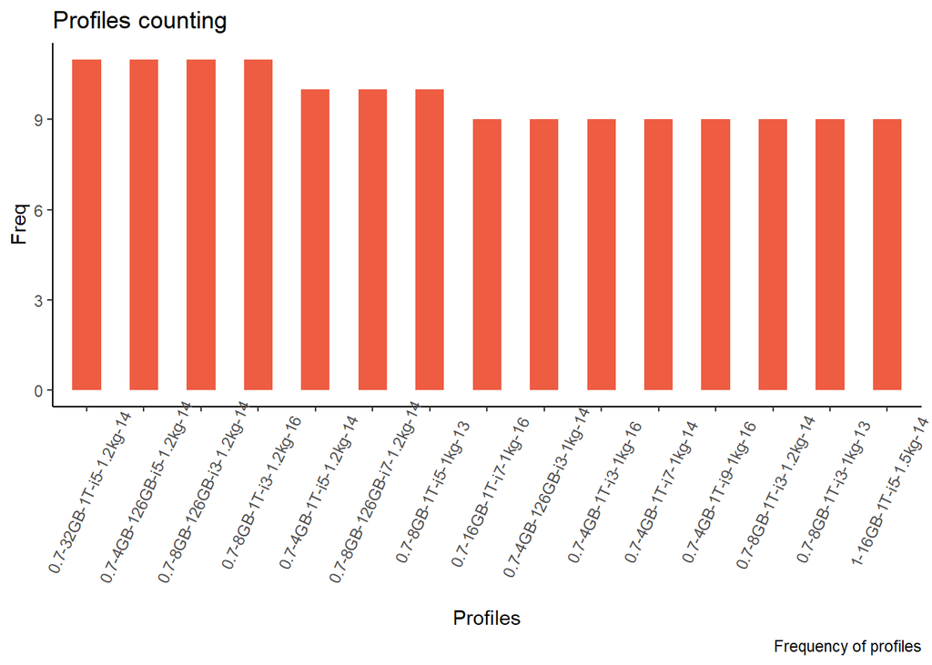

## Profiles chosen

```
##   Price  RAM Memory Processor Weight ScreenSize
## 1   0.7  4GB  126GB        i3  0.8kg         12
## 2     1  4GB  126GB        i3  1.2kg         13
## 3     1  8GB  256GB        i5    1kg         13
## 4   1.5 16GB  512GB        i7  1.5kg         16
## 5     2 16GB  512GB        i7  1.2kg         16
## 6     2 32GB     1T        i9  1.5kg         14
```

## Preference share prediction (Not representing sales)

```
##        share Price  RAM Memory Processor Weight ScreenSize
## 1 0.07703427   0.7  4GB  126GB        i3  0.8kg         12
## 2 0.38916300     1  4GB  126GB        i3  1.2kg         13
## 3 0.33561365     1  8GB  256GB        i5    1kg         13
## 4 0.04153977   1.5 16GB  512GB        i7  1.5kg         16
## 5 0.08664339     2 16GB  512GB        i7  1.2kg         16
## 6 0.07000592     2 32GB     1T        i9  1.5kg         14
```

## Trade-off attributes graph

```
##             level      share     increase
## Price1        0.7 0.19747557  0.110832174
## Price2          1 0.13605723  0.049413837
## Price3        1.5 0.12198107  0.035337675
## Price4          2 0.08664339  0.000000000
## RAM1          4GB 0.15901594  0.072372547
## RAM2          8GB 0.32263310  0.235989708
## RAM3         16GB 0.08664339  0.000000000
## RAM4         32GB 0.07738519 -0.009258204
## Memory1     126GB 0.20545569  0.118812301
## Memory2     256GB 0.08012462 -0.006518775
## Memory3     512GB 0.08664339  0.000000000
## Memory4        1T 0.41941327  0.332769875
## Processor1     i3 0.10250060  0.015857211
## Processor2     i5 0.12141244  0.034769049
## Processor3     i7 0.08664339  0.000000000
## Processor4     i9 0.03614466 -0.050498731
## Weight1     0.8kg 0.03566013 -0.050983261
## Weight2       1kg 0.07379948 -0.012843912
## Weight3     1.2kg 0.08664339  0.000000000
## Weight4     1.5kg 0.03011955 -0.056523846
## ScreenSize1    12 0.01259108 -0.074052314
## ScreenSize2    13 0.03775507 -0.048888325
## ScreenSize3    14 0.08085103 -0.005792357
## ScreenSize4    16 0.08664339  0.000000000
```

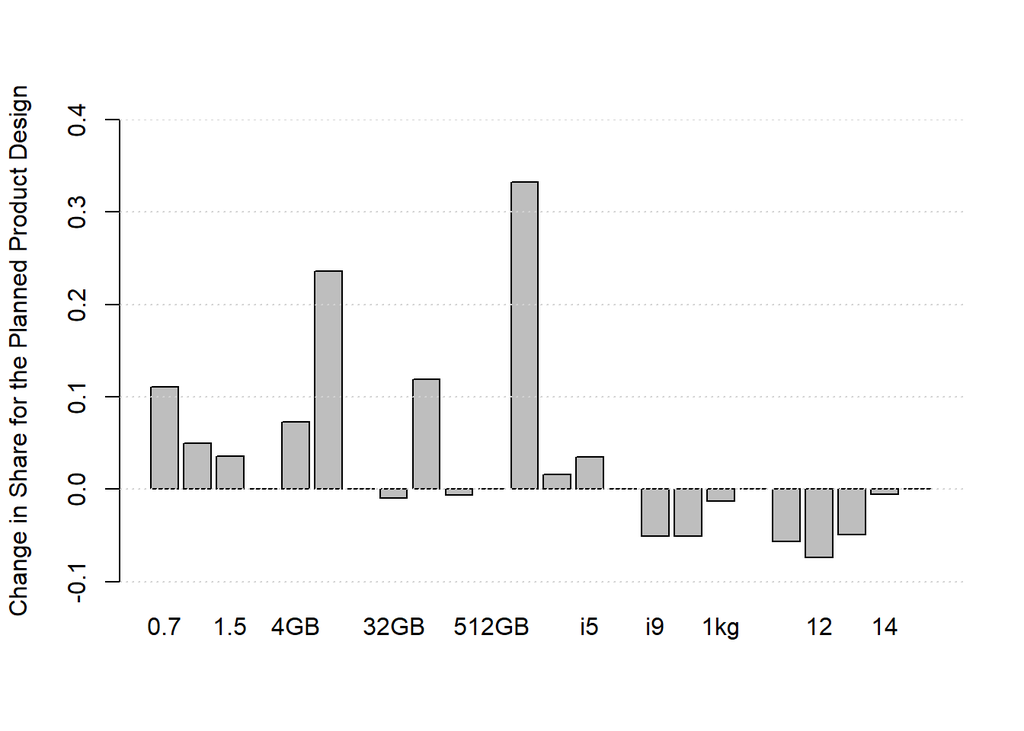

## Are our users homogeneous?

## Random Effect model

In order to verify that, we are going to create a model that takes in consideration random effects (variation according to respondents).

```r
lm2.mixed <- mlogit(choice ~ Price + RAM + Memory + Processor + Weight + ScreenSize  | -1,
                   data = laptops.mlogit,
                   panel=TRUE, rpar = lm2.rpar, correlation = FALSE)
summary(lm2.mixed)
```

```
##
## Call:
## mlogit(formula = choice ~ Price + RAM + Memory + Processor +
##     Weight + ScreenSize | -1, data = laptops.mlogit, rpar = lm2.rpar,
##     correlation = FALSE, panel = TRUE)
##
## Frequencies of alternatives:choice
##       1       2       3       4
## 0.24573 0.25267 0.25227 0.24933
##
## bfgs method
## 31 iterations, 0h:0m:52s
## g'(-H)^-1g = 1.14E-07
## gradient close to zero
##
## Coefficients :
##                  Estimate Std. Error  z-value  Pr(>|z|)
## Price1          -0.513206   0.050625 -10.1373 < 2.2e-16 ***
## Price1.5        -0.636052   0.051639 -12.3173 < 2.2e-16 ***
## Price2          -1.102139   0.054235 -20.3215 < 2.2e-16 ***
## RAM8GB           1.086620   0.050751  21.4107 < 2.2e-16 ***
## RAM16GB         -0.823429   0.056087 -14.6813 < 2.2e-16 ***
## RAM32GB         -0.921903   0.054573 -16.8929 < 2.2e-16 ***
## Memory256GB     -1.294880   0.056797 -22.7983 < 2.2e-16 ***
## Memory512GB     -1.216042   0.056786 -21.4145 < 2.2e-16 ***
## Memory1T         1.198006   0.051026  23.4781 < 2.2e-16 ***
## Processori5      0.197380   0.049440   3.9923 6.544e-05 ***
## Processori7     -0.223364   0.049995  -4.4677 7.906e-06 ***
## Processori9     -1.348028   0.057457 -23.4615 < 2.2e-16 ***
## Weight1kg        0.849019   0.054442  15.5950 < 2.2e-16 ***
## Weight1.2kg      1.080796   0.054020  20.0073 < 2.2e-16 ***
## Weight1.5kg     -0.204326   0.055704  -3.6681 0.0002444 ***
## ScreenSize13     1.299412   0.061869  21.0026 < 2.2e-16 ***
## ScreenSize14     2.200346   0.064643  34.0383 < 2.2e-16 ***
## ScreenSize16     2.332517   0.064499  36.1634 < 2.2e-16 ***
## sd.Price1       -0.454341   0.059929  -7.5813 3.419e-14 ***
## sd.Price1.5      0.682943   0.056733  12.0378 < 2.2e-16 ***
## sd.Price2        0.274326   0.062423   4.3946 1.110e-05 ***
## sd.RAM8GB       -0.027677   0.067640  -0.4092 0.6824128
## sd.RAM16GB       0.572349   0.069340   8.2542 2.220e-16 ***
```

[output cut: 23 more lines]

```
## RAM8GB       -Inf  1.0679522  1.0866197  1.0866197  1.10528728  Inf
## RAM16GB      -Inf -1.2094721 -0.8234287 -0.8234287 -0.43738531  Inf
## RAM32GB      -Inf -1.0277623 -0.9219033 -0.9219033 -0.81604444  Inf
## Memory256GB  -Inf -1.5641748 -1.2948803 -1.2948803 -1.02558567  Inf
## Memory512GB  -Inf -1.4780041 -1.2160421 -1.2160421 -0.95407999  Inf
## Memory1T     -Inf  1.0978769  1.1980059  1.1980059  1.29813498  Inf
## Processori5  -Inf -0.2793257  0.1973797  0.1973797  0.67408514  Inf
## Processori7  -Inf -0.4292685 -0.2233641 -0.2233641 -0.01745963  Inf
## Processori9  -Inf -1.6434746 -1.3480284 -1.3480284 -1.05258225  Inf
## Weight1kg    -Inf  0.4405982  0.8490192  0.8490192  1.25744022  Inf
## Weight1.2kg  -Inf  0.7876098  1.0807961  1.0807961  1.37398247  Inf
## Weight1.5kg  -Inf -0.4372061 -0.2043261 -0.2043261  0.02855392  Inf
## ScreenSize13 -Inf  1.2019834  1.2994124  1.2994124  1.39684141  Inf
## ScreenSize14 -Inf  1.6305741  2.2003463  2.2003463  2.77011846  Inf
## ScreenSize16 -Inf  2.2697799  2.3325170  2.3325170  2.39525412  Inf
```

## Disctribution of the random effects - Level of heterogeneity

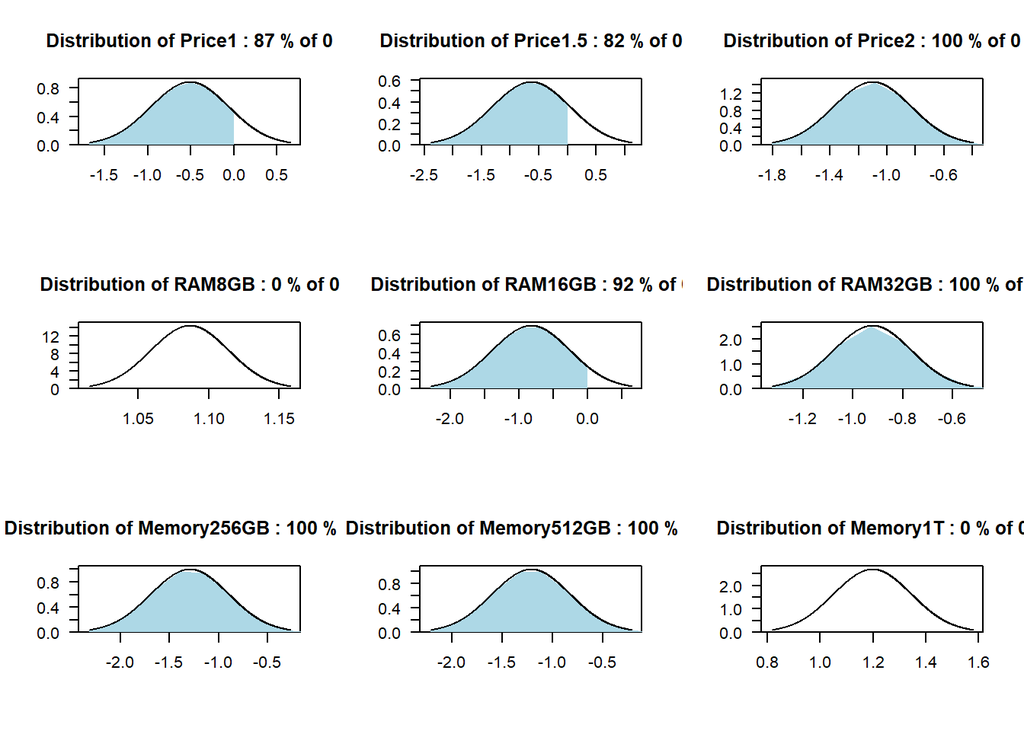

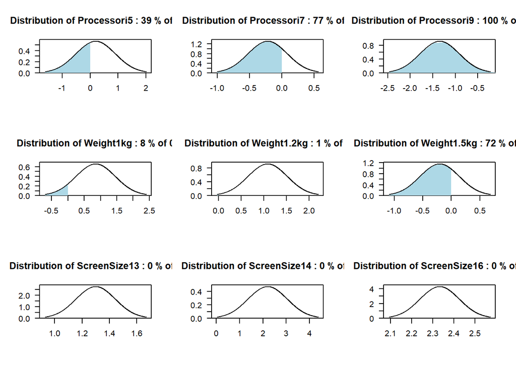

```r
#comparing the sign of the quantiles we can identify that Processori5 and Weight1.5kg have different signs, which could imply heterogeneity
par(mfrow=c(2,2))
processor5.distr <- rpar(lm2.mixed, "Processori5")
summary(processor5.distr)
```

```
##       Min.    1st Qu.     Median       Mean    3rd Qu.       Max.
##       -Inf -0.2793257  0.1973797  0.1973797  0.6740851        Inf
```

```r
mean(processor5.distr)
```

```
## [1] 0.1973797
```

```r
med(processor5.distr)
```

```
## [1] 0.1973797
```

```r
plot(processor5.distr)


Weight1.5kg.distr <- rpar(lm2.mixed, "Weight1.5kg")
summary(Weight1.5kg.distr)
```

```
##        Min.     1st Qu.      Median        Mean     3rd Qu.        Max.
##        -Inf -0.43720609 -0.20432608 -0.20432608  0.02855392         Inf
```

```r
mean(Weight1.5kg.distr)
```

```
## [1] -0.2043261
```

```r
med(Weight1.5kg.distr)
```

```
## [1] -0.2043261
```

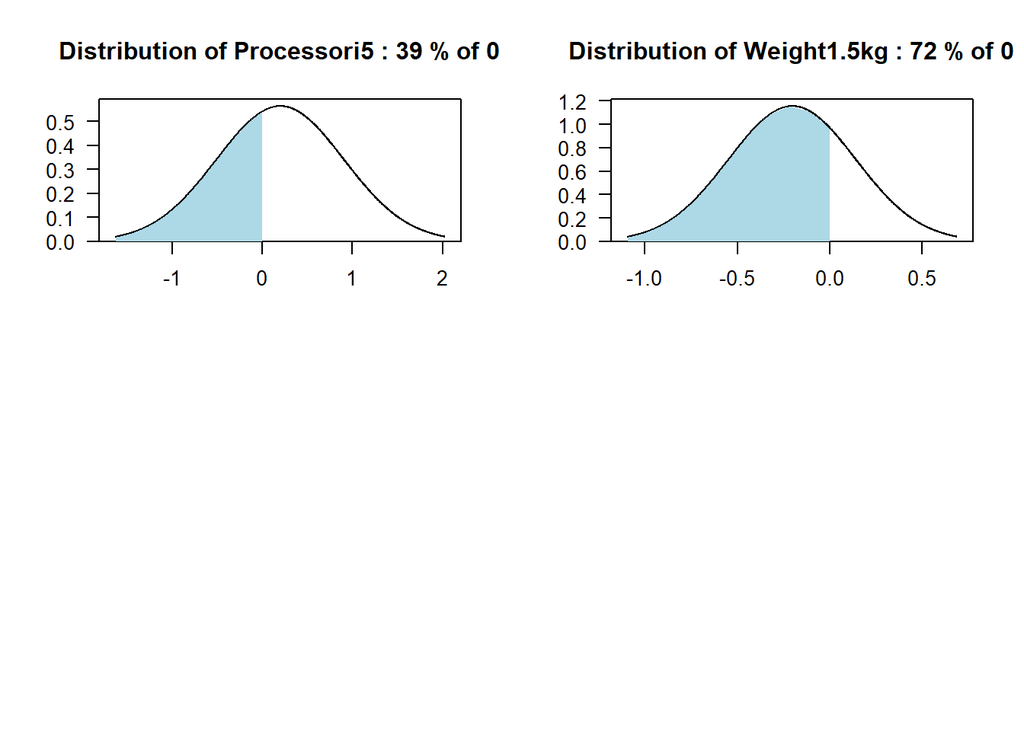

```r
plot(Weight1.5kg.distr)
```

## Correlated model It is reasonable to think that the variables can be correlated. In order to verify that, we are going to create a model that takes in consideration random effects (variation according to respondents) and that the random parameters are correlated. First we consider correlation among all pair of variables and analyse its covariance.

```r
lm2.mixed2 <- update(lm2.mixed, correlation = TRUE)
summary(lm2.mixed2)
```

```
##
## Call:
## mlogit(formula = choice ~ Price + RAM + Memory + Processor +
##     Weight + ScreenSize | -1, data = laptops.mlogit, rpar = lm2.rpar,
##     correlation = TRUE, panel = TRUE)
##
## Frequencies of alternatives:choice
##       1       2       3       4
## 0.24573 0.25267 0.25227 0.24933
##
## bfgs method
## 102 iterations, 0h:5m:51s
## g'(-H)^-1g = 5.41E-07
## gradient close to zero
##
## Coefficients :
##                                   Estimate  Std. Error  z-value  Pr(>|z|)
## Price1                         -0.54233281  0.05330925 -10.1733 < 2.2e-16 ***
## Price1.5                       -0.64478014  0.05552343 -11.6128 < 2.2e-16 ***
## Price2                         -1.18928303  0.05888731 -20.1959 < 2.2e-16 ***
## RAM8GB                          1.19315569  0.05460591  21.8503 < 2.2e-16 ***
## RAM16GB                        -0.98229374  0.06128734 -16.0277 < 2.2e-16 ***
## RAM32GB                        -0.98049318  0.05962395 -16.4446 < 2.2e-16 ***
## Memory256GB                    -1.43131141  0.06192802 -23.1125 < 2.2e-16 ***
## Memory512GB                    -1.26974013  0.06091744 -20.8436 < 2.2e-16 ***
## Memory1T                        1.31582316  0.05632211  23.3625 < 2.2e-16 ***
## Processori5                     0.29879387  0.05365480   5.5688 2.565e-08 ***
## Processori7                    -0.21623685  0.05527062  -3.9123 9.141e-05 ***
## Processori9                    -1.52812614  0.06605947 -23.1326 < 2.2e-16 ***
## Weight1kg                       0.97676614  0.05991144  16.3035 < 2.2e-16 ***
## Weight1.2kg                     1.21907707  0.06082259  20.0432 < 2.2e-16 ***
## Weight1.5kg                    -0.24957600  0.06229877  -4.0061 6.173e-05 ***
## ScreenSize13                    1.51490223  0.07231889  20.9475 < 2.2e-16 ***
## ScreenSize14                    2.48273505  0.07609799  32.6255 < 2.2e-16 ***
## ScreenSize16                    2.66480055  0.07588602  35.1158 < 2.2e-16 ***
## chol.Price1:Price1             -0.10464534  0.06080981  -1.7209 0.0852757 .
## chol.Price1:Price1.5            0.50918743  0.06463289   7.8781 3.331e-15 ***
## chol.Price1.5:Price1.5          0.53851493  0.05679775   9.4813 < 2.2e-16 ***
## chol.Price1:Price2             -0.03133363  0.06416510  -0.4883 0.6253174
## chol.Price1.5:Price2           -0.01748815  0.05926133  -0.2951 0.7679157
```

[output cut: 176 more lines]

```
## RAM8GB       -Inf  1.0703438  1.1931557  1.1931557  1.3159676  Inf
## RAM16GB      -Inf -1.3942001 -0.9822937 -0.9822937 -0.5703874  Inf
## RAM32GB      -Inf -1.2264055 -0.9804932 -0.9804932 -0.7345809  Inf
## Memory256GB  -Inf -1.7433814 -1.4313114 -1.4313114 -1.1192414  Inf
## Memory512GB  -Inf -1.6509456 -1.2697401 -1.2697401 -0.8885347  Inf
## Memory1T     -Inf  1.0624095  1.3158232  1.3158232  1.5692368  Inf
## Processori5  -Inf -0.1217108  0.2987939  0.2987939  0.7192986  Inf
## Processori7  -Inf -0.6344794 -0.2162368 -0.2162368  0.2020057  Inf
## Processori9  -Inf -2.1675998 -1.5281261 -1.5281261 -0.8886525  Inf
## Weight1kg    -Inf  0.4019923  0.9767661  0.9767661  1.5515400  Inf
## Weight1.2kg  -Inf  0.7207841  1.2190771  1.2190771  1.7173700  Inf
## Weight1.5kg  -Inf -0.7061830 -0.2495760 -0.2495760  0.2070310  Inf
## ScreenSize13 -Inf  1.0059290  1.5149022  1.5149022  2.0238755  Inf
## ScreenSize14 -Inf  1.6399673  2.4827351  2.4827351  3.3255028  Inf
## ScreenSize16 -Inf  2.0365154  2.6648005  2.6648005  3.2930857  Inf
```

```r
cov2cor(cov.mlogit(lm2.mixed2))
```

```
##                   Price1     Price1.5      Price2      RAM8GB      RAM16GB
## Price1        1.00000000 -0.687044183  0.33407312  0.10860838 -0.677357177
## Price1.5     -0.68704418  1.000000000 -0.36500435 -0.23164414 -0.001964564
## Price2        0.33407312 -0.365004352  1.00000000  0.15467773 -0.294073314
## RAM8GB        0.10860838 -0.231644138  0.15467773  1.00000000 -0.063199056
## RAM16GB      -0.67735718 -0.001964564 -0.29407331 -0.06319906  1.000000000
## RAM32GB       0.46400413 -0.250924657 -0.41191224  0.58451759 -0.319788258
## Memory256GB   0.54616025 -0.263727489 -0.04810343 -0.45817795 -0.198857976
## Memory512GB  -0.05506315  0.332139778 -0.26754143  0.41610824 -0.089702311
## Memory1T      0.23276658  0.098201829  0.27091114  0.15185407 -0.561025286
## Processori5  -0.17805894  0.111847564  0.18037118  0.62353224  0.023223852
## Processori7   0.15460179  0.045719359 -0.05725477 -0.64296668 -0.218732488
## Processori9   0.07820549 -0.391136495 -0.03158962  0.11129423  0.155902361
## Weight1kg     0.08106111 -0.183853198 -0.22650865  0.19118618  0.058105201
## Weight1.2kg   0.09313598 -0.045269600 -0.05639516 -0.14205431 -0.098547700
## Weight1.5kg   0.30890447 -0.199620366  0.04581885  0.21571613 -0.181654394
## ScreenSize13 -0.25736456  0.321899644 -0.33426606 -0.18742088  0.032521362
## ScreenSize14 -0.02437966  0.136258460  0.05543439 -0.27442235 -0.174163582
## ScreenSize16  0.04344272  0.217397414 -0.35305377 -0.12307525 -0.252440381
##                   RAM32GB  Memory256GB Memory512GB    Memory1T Processori5
## Price1        0.464004127  0.546160255 -0.05506315  0.23276658 -0.17805894
## Price1.5     -0.250924657 -0.263727489  0.33213978  0.09820183  0.11184756
## Price2       -0.411912244 -0.048103429 -0.26754143  0.27091114  0.18037118
## RAM8GB        0.584517595 -0.458177954  0.41610824  0.15185407  0.62353224
## RAM16GB      -0.319788258 -0.198857976 -0.08970231 -0.56102529  0.02322385
## RAM32GB       1.000000000  0.110412027  0.43191445  0.08346486  0.15483224
## Memory256GB   0.110412027  1.000000000  0.18894946 -0.17917021 -0.43976112
## Memory512GB   0.431914454  0.188949459  1.00000000  0.14537213  0.19834397
## Memory1T      0.083464856 -0.179170211  0.14537213  1.00000000 -0.08485591
## Processori5   0.154832239 -0.439761119  0.19834397 -0.08485591  1.00000000
## Processori7  -0.257926949  0.287672895 -0.35714155  0.31805327 -0.50978621
## Processori9   0.127012238 -0.265963580 -0.41921447  0.03922100  0.04411079
## Weight1kg     0.305480336 -0.106481865  0.05597285 -0.09863609 -0.25854741
## Weight1.2kg  -0.001826036  0.007056886 -0.31595760 -0.03504469  0.12162371
## Weight1.5kg   0.309079167  0.213244822  0.29129634  0.21259665 -0.10164774
## ScreenSize13 -0.019671256 -0.176461482 -0.13847219 -0.33144333 -0.02504435
## ScreenSize14 -0.244955118 -0.113184270 -0.31753787 -0.20517453 -0.13949621
## ScreenSize16  0.233715215 -0.007231263 -0.03945633 -0.19865984 -0.05212333
##              Processori7 Processori9   Weight1kg  Weight1.2kg Weight1.5kg
## Price1        0.15460179  0.07820549  0.08106111  0.093135976  0.30890447
```

[output cut: 21 more lines]

```
## RAM8GB        -0.18742088  -0.27442235 -0.123075252
## RAM16GB        0.03252136  -0.17416358 -0.252440381
## RAM32GB       -0.01967126  -0.24495512  0.233715215
## Memory256GB   -0.17646148  -0.11318427 -0.007231263
## Memory512GB   -0.13847219  -0.31753787 -0.039456334
## Memory1T      -0.33144333  -0.20517453 -0.198659840
## Processori5   -0.02504435  -0.13949621 -0.052123326
## Processori7   -0.05992128   0.05057417  0.054628592
## Processori9    0.21367891   0.01517149  0.213037394
## Weight1kg      0.10081021   0.14488302  0.192064565
## Weight1.2kg   -0.14738383   0.16235937  0.042563413
## Weight1.5kg   -0.03505430   0.21449723  0.136057703
## ScreenSize13   1.00000000   0.57610061  0.820028899
## ScreenSize14   0.57610061   1.00000000  0.507964027
## ScreenSize16   0.82002890   0.50796403  1.000000000
```

```r
summary(vcov(lm2.mixed2, what = "rpar", type = "cor"))
```

```
##                                 Estimate Std. Error z-value  Pr(>|z|)
## sd.Price1                      0.1046453  0.0608098  1.7209  0.085276 .
## sd.Price1.5                    0.7411276  0.0584025 12.6900 < 2.2e-16 ***
## sd.Price2                      0.0937927  0.0601420  1.5595  0.118873
## sd.RAM8GB                      0.1820812  0.0645132  2.8224  0.004767 **
## sd.RAM16GB                     0.6106933  0.0709156  8.6115 < 2.2e-16 ***
## sd.RAM32GB                     0.3645901  0.0718506  5.0743 3.890e-07 ***
## sd.Memory256GB                 0.4626757  0.0663338  6.9750 3.060e-12 ***
## sd.Memory512GB                 0.5651760  0.0696229  8.1177 4.752e-16 ***
## sd.Memory1T                    0.3757116  0.0627030  5.9919 2.074e-09 ***
## sd.Processori5                 0.6234412  0.0640201  9.7382 < 2.2e-16 ***
## sd.Processori7                 0.6200873  0.0637963  9.7198 < 2.2e-16 ***
## sd.Processori9                 0.9480850  0.0777781 12.1896 < 2.2e-16 ***
## sd.Weight1kg                   0.8521610  0.0723369 11.7805 < 2.2e-16 ***
## sd.Weight1.2kg                 0.7387702  0.0726530 10.1685 < 2.2e-16 ***
## sd.Weight1.5kg                 0.6769665  0.0686354  9.8632 < 2.2e-16 ***
## sd.ScreenSize13                0.7546049  0.0821778  9.1826 < 2.2e-16 ***
## sd.ScreenSize14                1.2494894  0.0786599 15.8847 < 2.2e-16 ***
## sd.ScreenSize16                0.9314969  0.0814374 11.4382 < 2.2e-16 ***
## cor.Price1:Price1.5           -0.6870442  0.6372867 -1.0781  0.280999
## cor.Price1:Price2              0.3340731  0.7125909  0.4688  0.639202
## cor.Price1.5:Price2           -0.3650044  0.7402928 -0.4931  0.621974
## cor.Price1:RAM8GB              0.1086084  0.7123676  0.1525  0.878823
## cor.Price1.5:RAM8GB           -0.2316441  0.4866664 -0.4760  0.634088
## cor.Price2:RAM8GB              0.1546777  0.7451379  0.2076  0.835555
## cor.Price1:RAM16GB            -0.6773572  0.9135783 -0.7414  0.458431
## cor.Price1.5:RAM16GB          -0.0019646  0.1785798 -0.0110  0.991223
## cor.Price2:RAM16GB            -0.2940733  1.0264361 -0.2865  0.774496
## cor.RAM8GB:RAM16GB            -0.0631991  0.4367045 -0.1447  0.884933
## cor.Price1:RAM32GB             0.4640041  0.6203368  0.7480  0.454468
## cor.Price1.5:RAM32GB          -0.2509247  0.2768118 -0.9065  0.364681
## cor.Price2:RAM32GB            -0.4119122  1.0179386 -0.4047  0.685732
## cor.RAM8GB:RAM32GB             0.5845176  0.3288016  1.7777  0.075450 .
## cor.RAM16GB:RAM32GB           -0.3197883  0.2850313 -1.1219  0.261888
## cor.Price1:Memory256GB         0.5461603  0.6041802  0.9040  0.366012
## cor.Price1.5:Memory256GB      -0.2637275  0.2379968 -1.1081  0.267813
## cor.Price2:Memory256GB        -0.0481034  0.8306166 -0.0579  0.953818
## cor.RAM8GB:Memory256GB        -0.4581780  0.5983102 -0.7658  0.443803
## cor.RAM16GB:Memory256GB       -0.1988580  0.2911282 -0.6831  0.494569
## cor.RAM32GB:Memory256GB        0.1104120  0.3185830  0.3466  0.728913
```

[output cut: 119 more lines]

```
## cor.RAM16GB:ScreenSize16      -0.2524404  0.2245690 -1.1241  0.260966
## cor.RAM32GB:ScreenSize16       0.2337152  0.2329983  1.0031  0.315824
## cor.Memory256GB:ScreenSize16  -0.0072313  0.2151751 -0.0336  0.973191
## cor.Memory512GB:ScreenSize16  -0.0394563  0.2058139 -0.1917  0.847970
## cor.Memory1T:ScreenSize16     -0.1986598  0.2785827 -0.7131  0.475778
## cor.Processori5:ScreenSize16  -0.0521233  0.2024691 -0.2574  0.796840
## cor.Processori7:ScreenSize16   0.0546286  0.1901970  0.2872  0.773943
## cor.Processori9:ScreenSize16   0.2130374  0.1392787  1.5296  0.126122
## cor.Weight1kg:ScreenSize16     0.1920646  0.1393485  1.3783  0.168109
## cor.Weight1.2kg:ScreenSize16   0.0425634  0.1739966  0.2446  0.806749
## cor.Weight1.5kg:ScreenSize16   0.1360577  0.1768027  0.7695  0.441570
## cor.ScreenSize13:ScreenSize16  0.8200289  0.0500627 16.3800 < 2.2e-16 ***
## cor.ScreenSize14:ScreenSize16  0.5079640  0.0623374  8.1486 3.681e-16 ***
## ---
## Signif. codes:  0 '***' 0.001 '**' 0.01 '*' 0.05 '.' 0.1 ' ' 1
```

By analysing the signs from variance-covariance, we can update the model to contain just the variables that are correlated.

```r
lm2.mixed3 <- update(lm2.mixed2, correlation = c("Price1.5", "RAM8GB","RAM16GB", "RAM32GB", "Memory256GB","Memory512GB", "Memory1T", "Processori5", "Processori7","Processori9", "Weight1kg", "Weight1.2kg", "Weight1.5kg", "ScreenSize13", "ScreenSize14", "ScreenSize16"))
```

## Choosing models part 2

We need to compare the two new models with the previously chosen one (Fixed effect, no intercept) in order to choose which one to use. Same steps as the first choice of model. ### Fixed effects vs. uncorrelated random effects

```r
lrtest(lm2, lm2.mixed) #Fixed effects vs. uncorrelated random effects
```

```
## Likelihood ratio test
##
## Model 1: choice ~ Price + RAM + Memory + Processor + Weight + ScreenSize |
##     -1
## Model 2: choice ~ Price + RAM + Memory + Processor + Weight + ScreenSize |
##     -1
##   #Df  LogLik Df  Chisq Pr(>Chisq)
## 1  18 -6751.7
## 2  36 -6404.9 18 693.65  < 2.2e-16 ***
## ---
## Signif. codes:  0 '***' 0.001 '**' 0.01 '*' 0.05 '.' 0.1 ' ' 1
```

### Random effects but Uncorrelated vs. Random effects + all correlated

```r
lrtest(lm2.mixed, lm2.mixed2) #Uncorrelated random effects vs. all correlated random effects
```

```
## Likelihood ratio test
##
## Model 1: choice ~ Price + RAM + Memory + Processor + Weight + ScreenSize |
##     -1
## Model 2: choice ~ Price + RAM + Memory + Processor + Weight + ScreenSize |
##     -1
##   #Df  LogLik  Df Chisq Pr(>Chisq)
## 1  36 -6404.9
## 2 189 -6144.3 153 521.3  < 2.2e-16 ***
## ---
## Signif. codes:  0 '***' 0.001 '**' 0.01 '*' 0.05 '.' 0.1 ' ' 1
```

### Random effects + all correlated vs. Random effects + Partially correlated

```r
lrtest(lm2.mixed2,lm2.mixed3) #partially correlated random effects vs. all correlated random effects
```

```
## Likelihood ratio test
##
## Model 1: choice ~ Price + RAM + Memory + Processor + Weight + ScreenSize |
##     -1
## Model 2: choice ~ Price + RAM + Memory + Processor + Weight + ScreenSize |
##     -1
##   #Df  LogLik  Df  Chisq Pr(>Chisq)
## 1 189 -6144.3
## 2 156 -6191.7 -33 94.812  6.887e-08 ***
## ---
## Signif. codes:  0 '***' 0.001 '**' 0.01 '*' 0.05 '.' 0.1 ' ' 1
```

## Preference share of the users

```r
set.seed(1234)
predict.mixed.mnl(lm2.mixed2, data=profiles)
```

```
##   colMeans(shares) Price  RAM Memory Processor Weight ScreenSize
## 1       0.05464268   0.7  4GB  126GB        i3  0.8kg         12
## 2       0.38868417     1  4GB  126GB        i3  1.2kg         13
## 3       0.35471598     1  8GB  256GB        i5    1kg         13
## 4       0.04651138   1.5 16GB  512GB        i7  1.5kg         16
## 5       0.07111094     2 16GB  512GB        i7  1.2kg         16
## 6       0.08433485     2 32GB     1T        i9  1.5kg         14
```

### Effects of individual part and individual-level predictors

```r
PW.ind <- fitted(lm2.mixed2, type = "parameters")
head(PW.ind)
```

```
##   id     Price1    Price1.5    Price2   RAM8GB    RAM16GB    RAM32GB
## 1  1 -0.3657811 -1.62490558 -1.093475 1.283102 -1.7421294 -0.7852214
## 2  2 -0.4553263 -0.59621066 -1.208543 1.075840 -1.7228910 -0.8415202
## 3  3 -0.5129085 -1.41943536 -1.148969 1.265987 -0.5380518 -0.9228320
## 4  4 -0.6431417 -0.06253858 -1.321621 1.269412 -0.6279619 -0.7506234
## 5  5 -0.5470193 -1.20563368 -1.156673 1.067121 -0.7794782 -1.3003684
## 6  6 -0.4970269 -1.35792590 -1.128102 1.220884 -0.7687191 -0.9790940
##   Memory256GB Memory512GB  Memory1T  Processori5 Processori7 Processori9
## 1   -1.256039  -1.4437595 1.5681809  0.076889885 -0.23750942 -1.92644599
## 2   -1.263700  -1.5073192 1.8610538 -0.257249235  0.67607089 -2.14114501
## 3   -1.286650  -1.6528899 0.7490987  0.759678973 -0.80071147 -1.67899677
## 4   -1.813827  -0.8278868 1.4359036 -0.148917259 -0.27446254 -1.93683590
## 5   -1.820903  -2.4130723 1.3700970 -0.009764605  0.45533497 -0.08076373
## 6   -1.243193  -1.1364115 1.6282862 -0.833002322  0.07197805 -0.76076381
##   Weight1kg Weight1.2kg Weight1.5kg ScreenSize13 ScreenSize14 ScreenSize16
## 1 0.9952269   1.0529275  -0.2935758    0.9550405     2.113482     2.005080
## 2 1.0191498   2.0725047   0.2695898    0.3491183     2.564121     1.585352
## 3 0.6372465   1.4343803  -0.7043718    1.1182186     2.076095     2.124813
## 4 2.2624221   1.0028505  -0.1544891    2.1765558     1.456686     4.078110
## 5 1.3013272   2.2484357  -0.6655220    1.7817762     3.160109     2.712075
## 6 0.7560246  -0.8907705   0.4188773    1.4470695     1.190435     1.773454
```